# Multiple Linear Regression on King County House Prices Dataset

## Assumptions of Multiple Linear Regression

1. Linearity - the relationship between the independent variables and dependent variable should be linear
2. Independence Of Errors - each data point’s error should be independent of other points’ errors (no observation should influence another)
3. Homoscedasticity - variance of the errors remains consistent across all values of the independent variable
4. Normality Of Errors - errors are normally distributed
5. Multicollinearity - whether independent variables in a linear regression equation are correlated

### Assumption 1: Linearity

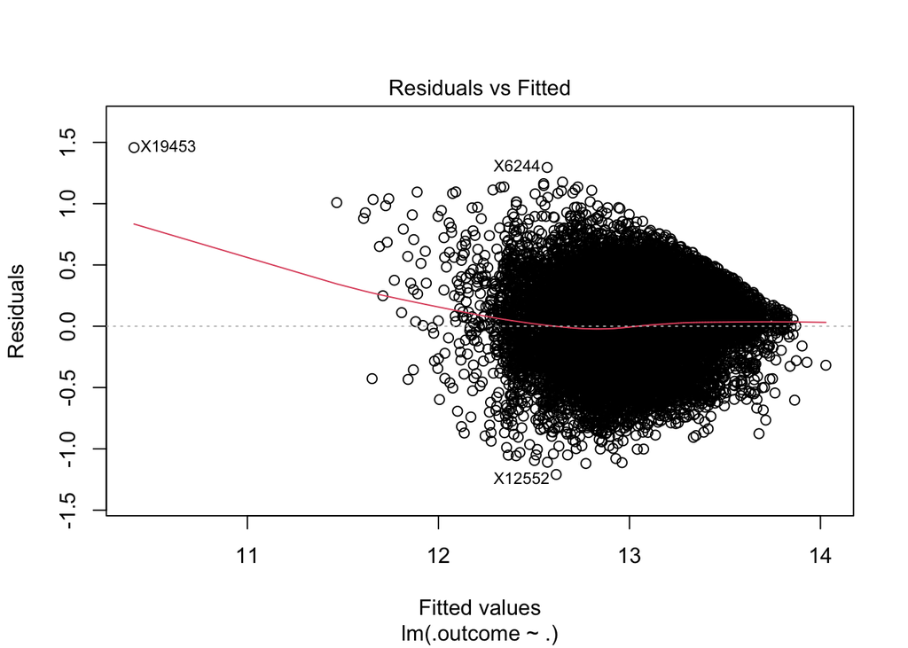

```r
plot(model$finalModel, 1)
```

### Assumption 2: Independence Of Errors

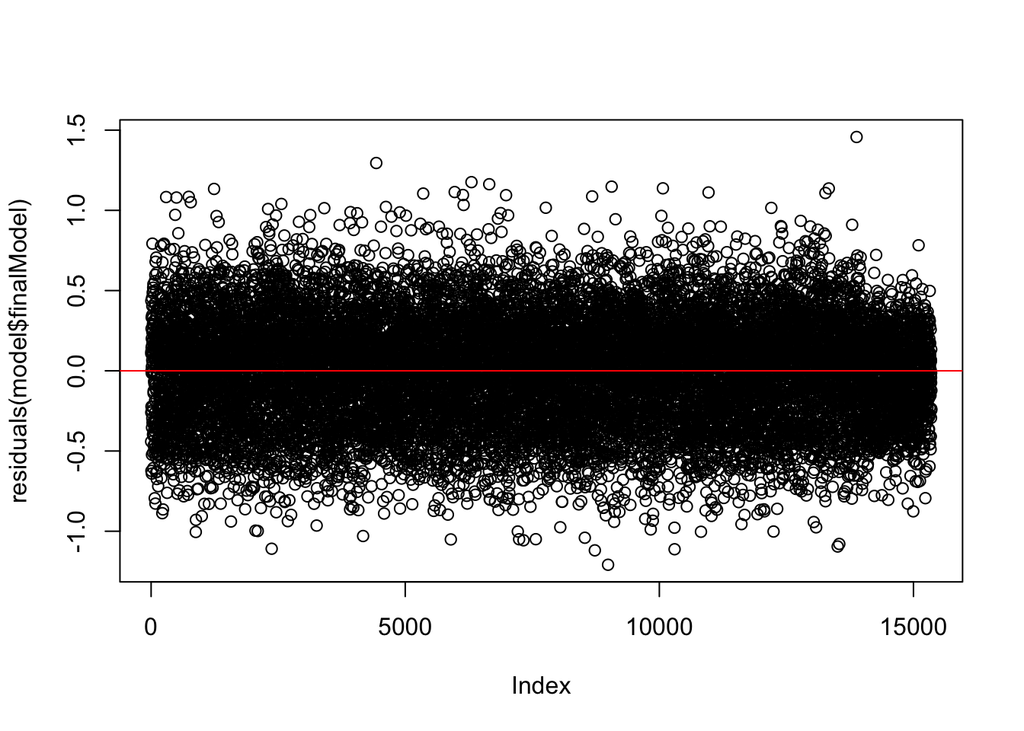

```r
plot(residuals(model$finalModel))
abline(h = 0, col='Red')
```

Our plot indicates the residuals are randomly scattered and centered around the horizontal line, indicating that the residuals are approximately equal to zero. We can also more formally verify that our errors are independent with a Durbin-Watson test. Given the large p-value, we fail to reject the null hypothesis. The autocorrelation is 0, or the errors are independent.

```r
dwtest(model$finalModel)
```

```
##
##  Durbin-Watson test
##
## data:  model$finalModel
## DW = 2.0007, p-value = 0.5174
## alternative hypothesis: true autocorrelation is greater than 0
```

### Assumption 3: Homoscedasticity

```r
bptest(model$finalModel)
```

```
##
##  studentized Breusch-Pagan test
##
## data:  model$finalModel
## BP = 578.19, df = 5, p-value < 2.2e-16
```

### Assumption 4: Normality Of Errors

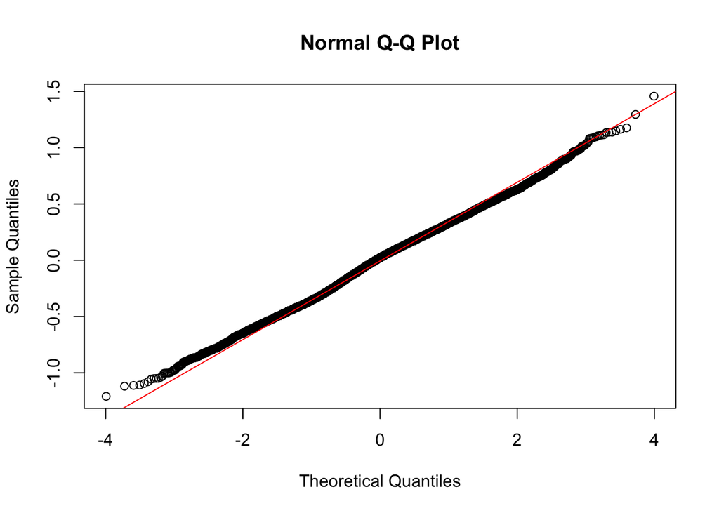

```r
qqnorm(residuals(model$finalModel))
qqline(residuals(model$finalModel), col='Red')
```

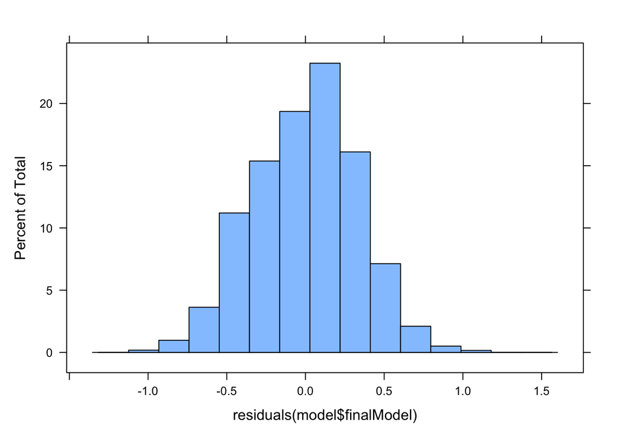

```r
histogram(residuals(model$finalModel), prob = TRUE)
```

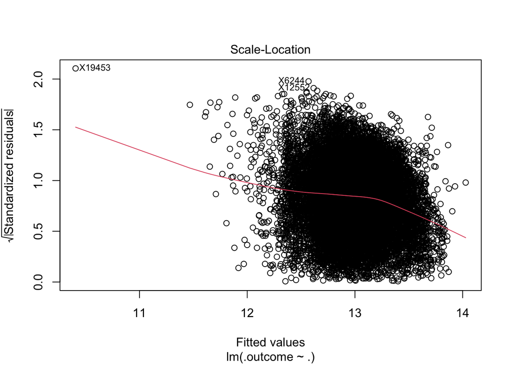

```r
plot(model$finalModel, 3)
```

### Assumption 5 - Multicollinearity

```r
vif(model$finalModel)
```

```
##    bedrooms   bathrooms sqft_living    sqft_lot       grade
##    1.791387    2.532892    4.111633    1.187548    2.148172
```

### Validity

# Model Evaluation and Prediction

```r
predictions <- predict(model, newdata = test)
actual <- test$price

mae <- mean(abs(predictions - actual)) # MAE
mse <- mean((predictions - actual)^2) # MSE
rmse <- sqrt(mse) # RMSE

cat("MAE: ", mae, "   MSE: ", mse, "   RMSE: ", rmse)
```

```
## MAE:  0.2645386    MSE:  0.1057127    RMSE:  0.3251349
```

In terms of model accuracy, we evaluated the residual statistics and key error metrics. These values indicate a reasonable predictive performance, though there is some variability in the residuals. The multiple R-squared value of 0.4492 suggests that approximately 44.9% of the variance in the outcome variable is explained by our predictors.

# Conclusion

The model provided meaningful insights into how different factors influence the outcome variable. Key predictors such as `sqft_living` and `grade` have significant positive impacts on price. However, the presence of heteroscedasticity suggests variability in residuals, which could impact predictive consistency. Furthermore, an R-squared of 0.4492 means over 45% of the variance remains unexplained.

Overall, while our model performs well within its scope, some future refinements can improve accuracy and generalizability.

# References

- https://www.kaggle.com/datasets/shivachandel/kc-house-data
- https://www.sthda.com/english/articles/40-regression-analysis/168-multiple-linear-regression-in-r/